# Head in the Game: Examining the Relationship Between Gaming and Mental Health

Simon Cao, Lilah Favour, Elora Hoberecht, Xuanyu Chen, Han Wang

1/22/2022

**Code Name**

**S.E.G.A** (**S**tudents **E**xploring **G**aming & **A**nxiety)

**Authors**

| Name | Email |
| --- | --- |
| Simon Cao | purunc@uw.edu |
| Lilah Favour | lfavour@uw.edu |
| Elora Hoberecht | elorahob@uw.edu |
| Xuanyu Chen | xuanyc2@uw.edu |
| Han Wang | hanw27@uw.edu |

**Affiliation**

INFO-201 Winter 2022: Technical Foundations of Informatics

The Information School - University of Washington

## Abstract

Our main question is what is the relationship between gaming and mental health, specifically anxiety. This question is important because gaming has become a popular pastime among people with various backgrounds and people who play games have often been characterized as antisocial and awkward, traits also associated with anxiety. To address this question we will perform various analyses on a dataset containing survey responses from gamers about their gaming habits, mental health, and socioeconomic background to see if there really is a trend.

## Keywords

Anxiety, Mental Health, Online Gaming

## Introduction

Despite the rapid advancement of technology and online environments in many aspects of our daily lives, video games are continuing to develop exponentially, and gaming communities are also growing. Along with being fun and entertaining, gaming can help people connect with each other, creating a sense of community as they work together to complete common tasks. Half of all Americans, 164 million people, play video games, also called gaming. Gaming isn’t just for teens, as popular belief would have you believe. According to a survey in 2019, only 21% of gamers were under 18 years old (Grinspoon, 2020). However, despite the benefits of gaming (even as it becomes a competitive sport on many college campuses), too much gaming is linked to health risks, and mental health issues arise among this growing body of diverse gamers. In this project, we are going to perform an analysis based on results from a series of questions, and also try to ravel out the relationship between the gaming habits of gamers and the latent mental health issues.

## Design Situation

**Project Framing:**

We hope to better understand how mental health and gaming habits are connected. Some research in the past has indicated that excessive gaming can contribute to negative mood and psychological well-being, such as increased depression/anxiety or the development of gaming addictions (Bhargava, H., 2021, Kowal, M., et al., 2021), while many users and other researchers find that gaming can serve as a very helpful stress reliever and help gamers relax or socialize with friends (Granic, I, et al., 2014).

**Human Values:**

The human values most important to our group in this project include human welfare and identity. We understand that for a lot of people who play games, being a ‘gamer’ is an important identity and valuable social community where people find belonging. Additionally, we hope to better understand how gaming impacts mental health, to help future researchers, designers, and practitioners make more informed decisions when choosing what kinds of games to play or modifying their own gaming habits to improve their overall well-being.

**Stakeholders:**

Gamers and game developers would be direct stakeholders, as they could be directly impacted by our findings and may find this data very useful. Members of the gaming community can use this information when deciding which games to play and how to play them, and developers may use this information to help facilitate healthy habits or create interactive worlds that minimize any harm and maximize any benefits that gaming provides to their players. Mental healthcare providers may also benefit from the findings/conclusions of this project, as it may provide new insights into how to best treat patients with conditions like depression and anxiety, or serve as a tool to help individuals struggling with social isolation (Kowal, M., 2021). Our indirect stakeholders include children and teens, who may not interact directly with our project, but may be impacted by our findings, as nearly 97% of children in the US play some type of video game for at least an hour a day (Granic, I., 2014).

**Harms and Benefits:**

Harms: It would not be a stretch to imagine scenarios in which the information in our project could be potentially useful to corporations seeking to find new ways of marketing their games or gaming products to consumers, and those struggling with mood disorders or feeling especially isolated may be particularly prone to manipulation in this way.

Benefits: This data may benefit people struggling with mental health disorders. We hope that our findings can benefit those struggling with mental health disorders or suffering with the effects of social isolation. Our findings may inform mental health practitioners on the ways in which gaming can be a tool to help mitigate the symptoms of these disorders, or inspire parents to enforce healthy gaming habits with children and adolescents.

## Research questions

- How does gaming affect mental health?
- Do different age groups matter with the relationship between gaming and mental health?
- How does gender affect the relationship between gaming and mental health?

These questions are important because first, if we want to find valid data, we have to think about different groups. For example, an answer might work for one group but not for another. After collecting datas using the survey, it is important to separate the data using different groups of people, so we can find if there is any pattern. Also, there might be different answers for different groups, too, for example, one age group might think that online gaming gives them anxiety and another might not.

## The Dataset

Our group intend to use the dataset: [Gaming Habits and Psychological Well-being: An international dataset about the Anxiety, Life Satisfaction and Social Phobia of over 13000 gamers](https://osf.io/vyr5f/).

- Who or what is represented in the data? What is an observation? What variables are included (and excluded)? The dataset contains about 13,000 data entries from gamers’ survey results and has 13 main variables of interest.

  **Variables of Interest**

  | Variable[s] | Type | Explanation |
  | --- | --- | --- |
  | Hours | num | Hours played |
  | streams | num | Additional hours dealing with games except playing |
  | Game | char | Game played the most |
  | SPIN_T and SPIN_T[1-17] | num | Social Phobia Inventory (SPIN) scores related data |
  | GAD_T and GAD[1-7] | num | Generalized Anxiety Disorder Screener (GAD-7) scores related data |
  | SWL_T and SWL[1-5] | num | Satisfaction with Life Scale (SWL) scores related data |
  | Narcissism | num | Score of the Single Item Narcissism Scale (SINS) |
  | Birthplace | char | Country of Birth |
  | Residence | char | Country of Residence |
  | Age | num | Age |
  | Work | char | Occupation status |
  | Degree | char | Highest degree |
  | Gender | char | Gender |

  The data is collected from 13464 gamers (12699 male, 713 female, 52 other) between 18 and 63 years. Participants resided in 109 different countries with most of the participants coming from the USA, Germany, the UK, and Canada. The participants responded to a call placed on Reddit and the survey was implemented in Google Forms.
- Who collected the data? When? For what purpose? How was the data collection effort funded? Who is likely to benefit from the data or make money?

  The data was collected in 2017 by 2 university researchers from Germany: Marian Sauter and Dejan Draschkow.

  (General and Experimental Psychology, Ludwig-Maximilians-Universität München, Munich, Germany)

  (Scene Grammar Lab, Goethe University Frankfurt, Frankfurt am Main, Germany)

  The dataset is gathered with a purpose of allowing more investigation of the relationship between excessive video game usage, well-being, and psychological disorders, and the authors declare that the research was conducted in the absence of any commercial or financial relationships that could be construed as a potential conflict of interest.
- How was the data validated and held secure? Is it credible and trustworthy?

  The dataset is validated as the full survey, dataset, preprocessing, as well as example analysis scripts are openly available online and is a product of a peer-reviewed research project.
- How did you obtain the data? Do you credit the source of the data?

  As the dataset is open source, our group will use the dataset freely from its publishing site and credit the source.

## Expected Implications

With more detailed relationships between gaming and mental health proved by data, technologists and designers (from game companies) could potentially provide more support in response to the mental health issue in gaming experience. For example, game developers could adopt game designs that prevent swearing and ease blaming between players; similarly, mechanisms that encourage more cooperation and provide more positive feedback to players could be built into existing frameworks. For policymakers, on the other hand, more restrictions could be applied to game companies to ensure they prioritize mental health in the entire life-cycle of game-development and operation. For instance, policies that mandate mental health support resources could be made, and potentially, an annual report on mental health profiles of the player-base could be requested by government officials.

## Limitations

By examining the dataset, our group noticed that the data is mainly from male gamers; also, the gamers that participated in this survey are mainly younger generations and from the western countries. Also, as the dataset is mainly gathered from Reddit and the survey is voluntary, there might be unforeseen limitations to the survey population. As a result, the conclusion may not apply well to all players, especially female players, older generations, and players in other regions; thus, we need to be careful when making conclusions about gamers in general.

## Exploratory Analysis of the Dataset

The dataset we are using is based on self-reported data from Reddit survey respondents. We filtered this dataset to include only respondents who are currently residing in the United States. Men made up the overwhelming majority of respondents, with men outnumbering women and ‘Other’ survey takers by a proportion of 13 to 1. The data set included respondents between the ages of 18 and 44 years old, though the average age was 21 years old. Survey takers reported spending an average of 31 hours spent either playing or watching games each week, though due to the nature of surveys it is possible that some respondents may have self-reported a number that is lower than reality. In addition, the majority of respondents preferred multiplayer online games, with 4252 (out of 4,569 respondents) listing multiplayer games as their primary play-style. The most popular game among respondents was League of Legends, which is not surprising given that this is an online multiplayer title. Overall, mental health scores were within normal ranges. The average result on the Life Satisfaction questionnaire was 20, which corresponds to a “slightly below average” overall life satisfaction rating. The average anxiety and social phobia scores were 5 and 20, respectively, which translates to a “low-risk” result for both anxiety and social phobia. This would suggest a potentially neutral relationship between mental health and gaming, however it is not possible to draw any meaningful conclusions about this data set that can be applied to the broader gaming community. More research is needed to better understand the relationship between gaming and mental health.

```r
summary_info
```

```
## $prop_men
## [1] 13
##
## $avg_time
## [1] 31
##
## $avg_age
## [1] 21
##
## $most_popular_game
## [1] "League of Legends"
##
## $num_multiplayer
## [1] 4252
##
## $avg_anxiety
## [1] 5
##
## $avg_satisfaction
## [1] 20
##
## $avg_phobia
## [1] 20
```

The following is a table grouped by gaming platforms and arranged in a descending order of the total player count. All numeric values are rounded to 2 decimal places. Noticiblely, players PC platform are the majority and spend the most time. Superisingly, it seems like they are also the group with the least mental health issues.

```r
agg_table
```

```
## # A tibble: 3 × 8
##   Platform        TotalPlayerCount MalePlayerCount FemalePlayerCou… AverageHours
##   <chr>                      <dbl>           <dbl>            <dbl>        <dbl>
## 1 PC                          4453            4137              295         20.5
## 2 Console (PS, X…              107              96               10         19.3
## 3 Smartphone / T…                9               8                1         16.8
## # … with 3 more variables: AverageGADScore <dbl>, AverageSWLScore <dbl>,
## #   AverageSPINScore <dbl>
```

The following bar chart gives answers to “Do different age groups matter with the relationship between gaming and anxiety.

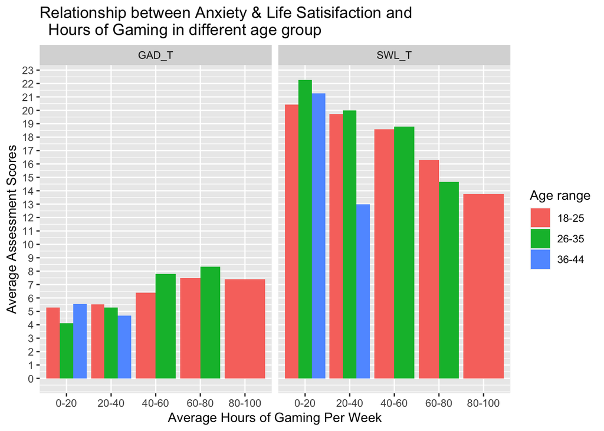

The following scatter plot is about anxiety level(GAD) vs. hours gaming.

This scatter plot was intended to demonstrate the relationship between anxiety levels and hours of games played per week, with respect to gender. Generalized Anxiety Disorder (GAD) Assessment scores were used to represent levels of anxiety. A score of 5-9 indicates mild anxiety, 10-14 indicates moderate anxiety and 15+ indicates severe anxiety. The hours of games played by everyone with a particular GAD score were averaged to give the average hours of games played per week. “Female”, “male”, and “other” were averaged and graphed separately. “Female” data points are colored red, “male” data points are colored green and “other” data points are colored blue, as shown in the key. The relationship between anxiety levels and gaming can be classified as positive for all gender categories, but none of the slopes are extremely positive. “Other” showed the strongest relationship with the greatest slope, meaning increasing anxiety levels are correlated with increasing hours of gaming. “Male” had a slightly less positive slope but “female” had the smallest correlation, with a slope of almost exactly zero. The regression line showed about a 2 hour increase from a GAD score of zero to a GAD score of 21, compared to an increase of roughly 10 hours for “other”.

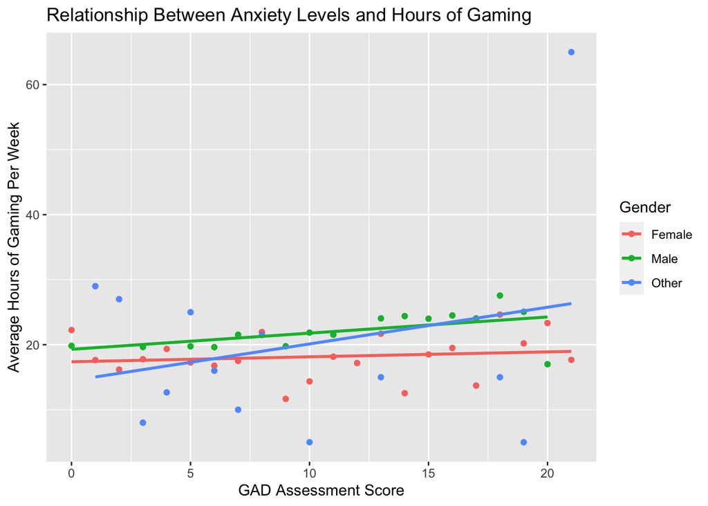

The following pie chart is about gamers anxiety level proportion in USA.

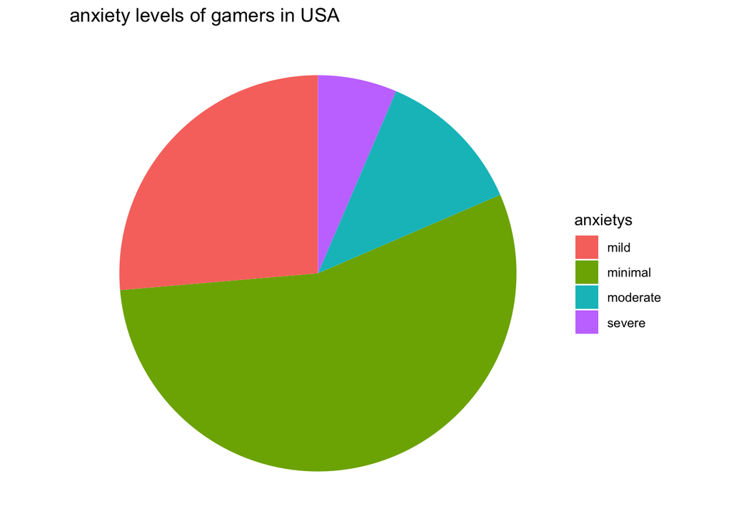

## Acknowledgements

We would like to thank Marian Sauter and Dejan Draschkow for collecting the data and sharing it online for free– this project would not have been possible without their expansive data set and research efforts.

## References

Bhargava, H. (2021, October 5). Hiding in plain sight: The impact of gaming on Mental Health. Forbes. Retrieved February 4, 2022, from https://www.forbes.com/sites/hansabhargava/2021/10/04/hiding-in-plain-sight-the-impact-of-gaming-on-mental-health/?sh=7f9b1325278d

Kowal, M., Conroy, E., Ramsbottom, N., Smithies, T., Toth, A., & Campbell, M. (2021). Gaming Your Mental Health: A Narrative Review on Mitigating Symptoms of Depression and Anxiety Using Commercial Video Games. JMIR serious games, 9(2), e26575. https://doi.org/10.2196/26575

Granic, I., Lobel, A., & Engels, R. C. M. E. (2014). The benefits of playing video games. American Psychologist, 69(1), https://doi.apa.org/doiLanding?doi=10.1037%2Fa0034857

Draschkow, D., & Sauter, M. (2017, October 30). Gaming habits and psychological well-being: An international dataset about the anxiety, life satisfaction and social phobia of over 13000 gamers. OSF. Retrieved February 4, 2022, from https://osf.io/vyr5f/

Grinspoon, P., MD. (2020, December 22). The health effects of too much gaming. Harvard Health. https://www.health.harvard.edu/blog/the-health-effects-of-too-much-gaming-2020122221645